# FIGI HRT Previously identified SNPs

AK

2022-02-10

## FIGI HRT - Supplemental Table5

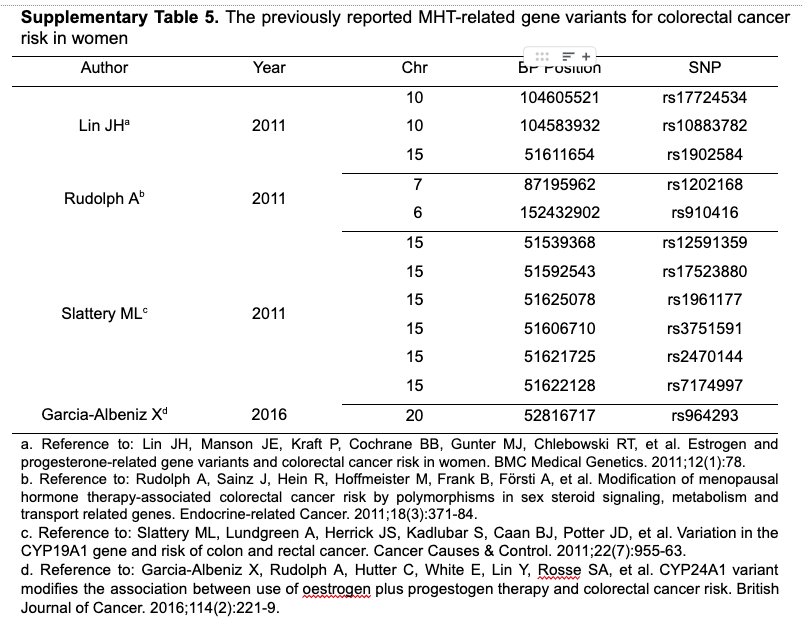

## FIGI results for the SNPs above

```r
x <- read.csv("~/Dropbox/Working/figi_hrt_response/hrt_ref_pm2_literature_snps.csv")

DT::datatable(x)
```

|  | SNP | Chromosome | Location | Subjects | Cases | chiSqG_p | chiSqGxE_p | chiSqGE_p | chiSqCase_p | chiSqControl_p | chiSq2df_p | chiSq3df_p |
| --- | --- | --- | --- | --- | --- | --- | --- | --- | --- | --- | --- | --- |
| 1 | 15:51539368:G:A | 15 | 51539368 | 28486 | 11519 | 0.265157144 | 0.847290261 | 0.682259008 | 0.968193838 | 0.438178827 | 0.527632637 | 0.69471623 |
| 2 | 15:51592543:C:A | 15 | 51592543 | 28486 | 11519 | 0.967888889 | 0.300081939 | 0.735792778 | 0.212284181 | 0.491069975 | 0.584075514 | 0.755569446 |
| 3 | 15:51606710:A:G | 15 | 51606710 | 28486 | 11519 | 0.643317153 | 0.637947171 | 0.741514476 | 0.78740745 | 0.981579486 | 0.804178918 | 0.908974216 |
| 4 | 15:51611654:A:T | 15 | 51611654 | 28486 | 11519 | 0.271191554 | 0.088951322 | 0.670234454 | 0.494894712 | 0.193747356 | 0.128480261 | 0.232260451 |
| 5 | 15:51621725:T:C | 15 | 51621725 | 28486 | 11519 | 0.737751221 | 0.872504031 | 0.402243239 | 0.707670383 | 0.455057904 | 0.933389215 | 0.84000334 |
| 6 | 15:51622128:G:T | 15 | 51622128 | 28486 | 11519 | 0.608414629 | 0.204542414 | 0.556802959 | 0.140600013 | 0.612557137 | 0.392167984 | 0.528529251 |
| 7 | 15:51625078:C:T | 15 | 51625078 | 28486 | 11519 | 0.079902196 | 0.11349485 | 0.176604292 | 0.71178558 | 0.016343369 | 0.061674791 | 0.06024526 |
| 8 | 20:52816717:C:A | 20 | 52816717 | 28486 | 11519 | 0.751725256 | 0.423043123 | 0.005504916 | 0.038383419 | 0.059345565 | 0.690067403 | 0.037613396 |
| 9 | 10:104583932:A:G | 10 | 104583932 | 28486 | 11519 | 0.413418274 | 0.891648492 | 0.400175127 | 0.637164313 | 0.514877965 | 0.709104764 | 0.706635751 |
| 10 | 10:104605521:C:T | 10 | 104605521 | 28486 | 11519 | 0.204892887 | 0.8703109 | 0.578881104 | 0.536118105 | 0.988758606 | 0.441799111 | 0.584562817 |

[output cut: 2 more lines]

## Lin JH et al

WHI study, reported SNP main effects for candidate gene analysis

### Table from Lin et al

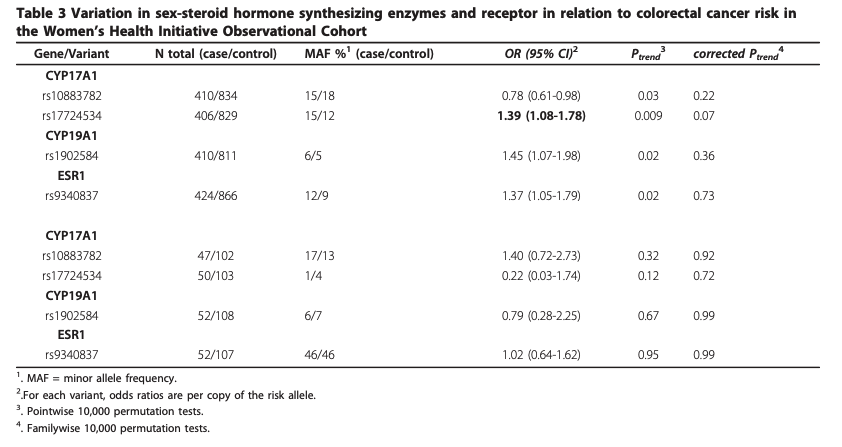

### FIGI HRT WHI only results

SNP Main effect, adjusted for age + pc1-3

```r
# WHI - main effects
rs17724534 <- qread("/media/work/gwis_test/hrt_ref_pm2/output/posthoc/dosage_chr10_104605521.qs") %>%
  rename(snp = chr10_104605521_C_T_dose)
rs10883782 <- qread("/media/work/gwis_test/hrt_ref_pm2/output/posthoc/dosage_chr10_104583932.qs") %>%
  rename(snp = chr10_104583932_A_G_dose)
rs1902584 <- qread("/media/work/gwis_test/hrt_ref_pm2/output/posthoc/dosage_chr15_51611654.qs") %>%
  rename(snp = chr15_51611654_A_T_dose)

whi <- filter(input_data, grepl("WHI", study_gxe))

# no nominal significance when using all WHI studies ..
rs17724534_dg <- glm(outcome ~ snp + age_ref_imp + pc1 + pc2 + pc3,
                     data = inner_join(whi, rs17724534, 'vcfid'), family = 'binomial')
# summary(rs17724534_dg)

rs10883782_dg <- glm(outcome ~ snp + age_ref_imp + pc1 + pc2 + pc3,
                     data = inner_join(whi, rs10883782, 'vcfid'), family = 'binomial')
# summary(rs10883782_dg)

rs1902584_dg <- glm(outcome ~ snp + age_ref_imp + pc1 + pc2 + pc3,
                     data = inner_join(whi, rs1902584, 'vcfid'), family = 'binomial')
# summary(rs1902584_dg)

list_of_glms <- list(rs17724534_dg, rs10883782_dg, rs1902584_dg)
coefs <- lapply(list_of_glms, function(x) (exp(coef(x))))

stargazer(list_of_glms, align = T,
          type = 'html',
          ci = TRUE,
          ci.level = 0.95,
          keep.stat = "n",
          star.cutoffs = c(0.05, 0.01, 0.001),
          coef = coefs,
          omit = c("pc"),
          p.auto = F,
          single.row = T,
          column.sep.width = '20pt',
          report = ('vcsp'),
          column.labels = c("rs17724534", "rs10883782", "rs1902584"))
```

|  | *Dependent variable:* |  |  |
| --- | --- | --- | --- |
|  | outcome |  |  |
|  | rs17724534 | rs10883782 | rs1902584 |
|  | (1) | (2) | (3) |
| snp | 1.032 (0.903, 1.161) | 0.906 (0.789, 1.022) | 0.892 (0.730, 1.053) |
|  | p = 0.631 | p = 0.097 | p = 0.166 |
| age_ref_imp | 1.004 (0.995, 1.014) | 1.005 (0.995, 1.014) | 1.004 (0.995, 1.014) |
|  | p = 0.372 | p = 0.337 | p = 0.363 |
| Constant | 0.885 (0.206, 1.564) | 0.900 (0.221, 1.579) | 0.908 (0.228, 1.587) |
|  | p = 0.724 | p = 0.761 | p = 0.781 |
| Observations | 4,050 | 4,050 | 4,050 |
| *Note:* | p<0.05; p<0.01; p<0.001 |  |  |

## Rudolph A et al

- DACHS study - GxE findings
- candidate gene approach
- Overall, 746 (92.0%) female cases and 732 (94.6%) female controls
- they didn’t identify main effects, these are GxE results (HRT x G)

### Table from Rudolph et al

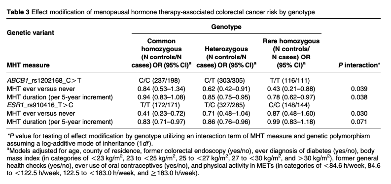

### FIGI HRT DACHS only results

Interaction test results, adjusted for age + pc1-3 + study_gxe

```r
dachs <- filter(input_data, grepl("DACHS", study_gxe))

rs1202168 <- qread("/media/work/gwis_test/hrt_ref_pm2/output/posthoc/dosage_chr6_152432902.qs") %>%
  rename(snp = chr6_152432902_C_T_dose)

rs1202168_1 <- glm(outcome ~ snp * hrt_ref_pm2 + age_ref_imp + pc1 + pc2 + pc3,
                    data = inner_join(dachs, rs1202168, 'vcfid') %>%
                     filter(study_gxe == "DACHS_1"), family = 'binomial')
# summary(rs910416_dg)

rs1202168_2 <- glm(outcome ~ snp * hrt_ref_pm2 + age_ref_imp + pc1 + pc2 + pc3,
                    data = inner_join(dachs, rs1202168, 'vcfid') %>%
                     filter(study_gxe == "DACHS_2"), family = 'binomial')

rs1202168_3 <- glm(outcome ~ snp * hrt_ref_pm2 + age_ref_imp + pc1 + pc2 + pc3,
                    data = inner_join(dachs, rs1202168, 'vcfid') %>%
                     filter(study_gxe == "DACHS_3"), family = 'binomial')

rs1202168_12 <- glm(outcome ~ snp * hrt_ref_pm2 + age_ref_imp + pc1 + pc2 + pc3 + study_gxe,
                    data = inner_join(dachs, rs1202168, 'vcfid') %>%
                     filter(study_gxe %in% c("DACHS_1", "DACHS_2")), family = 'binomial')

rs1202168_123 <- glm(outcome ~ snp * hrt_ref_pm2 + age_ref_imp + pc1 + pc2 + pc3 + study_gxe,
                    data = inner_join(dachs, rs1202168, 'vcfid') %>%
                     filter(study_gxe %in% c("DACHS_1", "DACHS_2", "DACHS_3")), family = 'binomial')



list_of_glms <- list(rs1202168_1, rs1202168_2, rs1202168_3, rs1202168_12, rs1202168_123)
coefs <- lapply(list_of_glms, function(x) (exp(coef(x))))

stargazer(list_of_glms, align = T,
          type = 'html',
          ci = TRUE,
          ci.level = 0.95,
          keep.stat = "n",
          star.cutoffs = c(0.05, 0.01, 0.001),
          coef = coefs,
          omit = c("pc"),
          p.auto = F,
          single.row = T,
          column.sep.width = '20pt',
          report = ('vcsp'),
          column.labels = c("dachs1", "dachs2", "dachs3", "dachs1+dachs2", "dachs1+2+3"))
```

|  | *Dependent variable:* |  |  |  |  |
| --- | --- | --- | --- | --- | --- |
|  | outcome |  |  |  |  |
|  | dachs1 | dachs2 | dachs3 | dachs1+dachs2 | dachs1+2+3 |
|  | (1) | (2) | (3) | (4) | (5) |
| snp | 1.106 (0.896, 1.315) | 0.797 (0.430, 1.164) | 0.985 (0.677, 1.294) | 1.021 (0.840, 1.202) | 1.013 (0.856, 1.169) |
|  | p = 0.347 | p = 0.226 | p = 0.924 | p = 0.824 | p = 0.875 |
| hrt_ref_pm2Yes | 0.593 (0.191, 0.996) | 0.424 (-0.294, 1.141) | 0.726 (0.100, 1.353) | 0.546 (0.196, 0.896) | 0.588 (0.284, 0.892) |
|  | p = 0.012 | p = 0.020 | p = 0.318 | p = 0.001 | p = 0.001 |
| age_ref_imp | 0.994 (0.982, 1.007) | 0.992 (0.970, 1.014) | 1.010 (0.992, 1.028) | 0.994 (0.983, 1.006) | 0.999 (0.990, 1.009) |
|  | p = 0.406 | p = 0.476 | p = 0.280 | p = 0.334 | p = 0.845 |
| study_gxeDACHS_2 |  |  |  | 1.338 (1.102, 1.573) | 1.341 (1.106, 1.575) |
|  |  |  |  | p = 0.016 | p = 0.015 |
| study_gxeDACHS_3 |  |  |  |  | 2.017 (1.810, 2.224) |
|  |  |  |  |  | p = 0.000 |
| snp:hrt_ref_pm2Yes | 0.739 (0.413, 1.066) | 1.130 (0.555, 1.705) | 0.800 (0.307, 1.292) | 0.821 (0.538, 1.103) | 0.824 (0.580, 1.068) |
|  | p = 0.070 | p = 0.678 | p = 0.374 | p = 0.171 | p = 0.121 |
| Constant | 2.823 (1.681, 3.965) | 3.812 (1.818, 5.805) | 1.040 (-0.430, 2.511) | 2.670 (1.686, 3.655) | 1.587 (0.771, 2.404) |
|  | p = 0.075 | p = 0.189 | p = 0.958 | p = 0.051 | p = 0.268 |
| Observations | 1,260 | 391 | 615 | 1,651 | 2,266 |
| *Note:* | p<0.05; p<0.01; p<0.001 |  |  |  |  |

```r
dachs <- filter(input_data, grepl("DACHS", study_gxe))

rs910416 <- qread("/media/work/gwis_test/hrt_ref_pm2/output/posthoc/dosage_chr7_87195962.qs") %>%
  rename(snp = chr7_87195962_G_A_dose)



rs910416_1 <- glm(outcome ~ snp * hrt_ref_pm2 + age_ref_imp + pc1 + pc2 + pc3,
                    data = inner_join(dachs, rs910416, 'vcfid') %>%
                     filter(study_gxe == "DACHS_1"), family = 'binomial')
# summary(rs910416_dg)

rs910416_2 <- glm(outcome ~ snp * hrt_ref_pm2 + age_ref_imp + pc1 + pc2 + pc3,
                    data = inner_join(dachs, rs910416, 'vcfid') %>%
                     filter(study_gxe == "DACHS_2"), family = 'binomial')

rs910416_3 <- glm(outcome ~ snp * hrt_ref_pm2 + age_ref_imp + pc1 + pc2 + pc3,
                    data = inner_join(dachs, rs910416, 'vcfid') %>%
                     filter(study_gxe == "DACHS_3"), family = 'binomial')

rs910416_12 <- glm(outcome ~ snp * hrt_ref_pm2 + age_ref_imp + pc1 + pc2 + pc3 + study_gxe,
                    data = inner_join(dachs, rs910416, 'vcfid') %>%
                     filter(study_gxe %in% c("DACHS_1", "DACHS_2")), family = 'binomial')

rs910416_123 <- glm(outcome ~ snp * hrt_ref_pm2 + age_ref_imp + pc1 + pc2 + pc3 + study_gxe,
                    data = inner_join(dachs, rs910416, 'vcfid') %>%
                     filter(study_gxe %in% c("DACHS_1", "DACHS_2", "DACHS_3")), family = 'binomial')



list_of_glms <- list(rs910416_1, rs910416_2, rs910416_3, rs910416_12, rs910416_123)
coefs <- lapply(list_of_glms, function(x) (exp(coef(x))))

stargazer(list_of_glms, align = T,
          type = 'html',
          ci = TRUE,
          ci.level = 0.95,
          keep.stat = "n",
          star.cutoffs = c(0.05, 0.01, 0.001),
          coef = coefs,
          omit = c("pc"),
          p.auto = F,
          single.row = T,
          column.sep.width = '20pt',
          report = ('vcsp'),
          column.labels = c("dachs1", "dachs2", "dachs3", "dachs1+dachs2", "dachs1+2+3"))
```

|  | *Dependent variable:* |  |  |  |  |
| --- | --- | --- | --- | --- | --- |
|  | outcome |  |  |  |  |
|  | dachs1 | dachs2 | dachs3 | dachs1+dachs2 | dachs1+2+3 |
|  | (1) | (2) | (3) | (4) | (5) |
| snp | 1.331 (1.115, 1.547) | 1.201 (0.814, 1.588) | 1.097 (0.792, 1.401) | 1.308 (1.120, 1.497) | 1.240 (1.080, 1.400) |
|  | p = 0.010 | p = 0.354 | p = 0.553 | p = 0.006 | p = 0.009 |
| hrt_ref_pm2Yes | 0.644 (0.278, 1.009) | 0.836 (0.153, 1.518) | 0.832 (0.273, 1.391) | 0.674 (0.354, 0.994) | 0.714 (0.438, 0.989) |
|  | p = 0.019 | p = 0.607 | p = 0.519 | p = 0.016 | p = 0.017 |
| age_ref_imp | 0.996 (0.983, 1.009) | 0.993 (0.971, 1.015) | 1.010 (0.992, 1.028) | 0.995 (0.984, 1.007) | 1.000 (0.990, 1.009) |
|  | p = 0.513 | p = 0.537 | p = 0.270 | p = 0.417 | p = 0.978 |
| study_gxeDACHS_2 |  |  |  | 1.365 (1.129, 1.601) | 1.365 (1.131, 1.600) |
|  |  |  |  | p = 0.010 | p = 0.010 |
| study_gxeDACHS_3 |  |  |  |  | 2.017 (1.810, 2.224) |
|  |  |  |  |  | p = 0.000 |
| snp:hrt_ref_pm2Yes | 0.637 (0.305, 0.969) | 0.527 (-0.112, 1.167) | 0.646 (0.143, 1.149) | 0.617 (0.323, 0.911) | 0.630 (0.377, 0.883) |
|  | p = 0.008 | p = 0.050 | p = 0.089 | p = 0.002 | p = 0.0004 |
| Constant | 2.207 (1.064, 3.350) | 2.435 (0.476, 4.394) | 0.943 (-0.534, 2.420) | 2.045 (1.062, 3.029) | 1.268 (0.452, 2.085) |
|  | p = 0.175 | p = 0.374 | p = 0.938 | p = 0.154 | p = 0.569 |
| Observations | 1,260 | 391 | 615 | 1,651 | 2,266 |
| *Note:* | p<0.05; p<0.01; p<0.001 |  |  |  |  |

### FIGI HRT Overall results

Interaction test results, adjusted for age + pc1-3 + study_gxe

```r
# dachs <- filter(input_data, grepl("DACHS", study_gxe))

rs1202168 <- qread("/media/work/gwis_test/hrt_ref_pm2/output/posthoc/dosage_chr6_152432902.qs") %>%
  rename(snp = chr6_152432902_C_T_dose)
rs1202168_dg <- glm(outcome ~ snp * hrt_ref_pm2 + age_ref_imp + pc1 + pc2 + pc3 + study_gxe,
                     data = inner_join(input_data, rs1202168, 'vcfid'), family = 'binomial')
# summary(rs1202168_dg)

rs910416 <- qread("/media/work/gwis_test/hrt_ref_pm2/output/posthoc/dosage_chr7_87195962.qs") %>%
  rename(snp = chr7_87195962_G_A_dose)
rs910416_dg <- glm(outcome ~ snp * hrt_ref_pm2 + age_ref_imp + pc1 + pc2 + pc3 + study_gxe,
                    data = inner_join(input_data, rs910416, 'vcfid'), family = 'binomial')
# summary(rs910416_dg)

list_of_glms <- list(rs1202168_dg, rs910416_dg)
coefs <- lapply(list_of_glms, function(x) (exp(coef(x))))

stargazer(list_of_glms, align = T,
          type = 'html',
          ci = TRUE,
          ci.level = 0.95,
          keep.stat = "n",
          star.cutoffs = c(0.05, 0.01, 0.001),
          coef = coefs,
          omit = c("pc"),
          p.auto = F,
          single.row = T,
          column.sep.width = '20pt',
          report = ('vcsp'),
          column.labels = c("rs1202168", "rs910416"))
```

|  | *Dependent variable:* |  |
| --- | --- | --- |
|  | outcome |  |
|  | rs1202168 | rs910416 |
|  | (1) | (2) |
| snp | 1.019 (0.974, 1.063) | 0.987 (0.942, 1.032) |
|  | p = 0.419 | p = 0.566 |
| hrt_ref_pm2Yes | 0.736 (0.642, 0.831) | 0.707 (0.622, 0.793) |
|  | p = 0.000 | p = 0.000 |
| age_ref_imp | 0.997 (0.994, 1.001) | 0.997 (0.994, 1.001) |
|  | p = 0.158 | p = 0.161 |
| study_gxeCCFR_3 | 2.445 (2.221, 2.668) | 2.445 (2.222, 2.669) |
|  | p = 0.000 | p = 0.000 |
| study_gxeCCFR_4 | 4.634 (4.372, 4.895) | 4.633 (4.372, 4.894) |
|  | p = 0.000 | p = 0.000 |
| study_gxeCLUEII | 1.414 (1.105, 1.723) | 1.413 (1.104, 1.722) |
|  | p = 0.028 | p = 0.029 |
| study_gxeColo23 | 1.326 (0.857, 1.794) | 1.325 (0.857, 1.793) |
|  | p = 0.239 | p = 0.239 |
| study_gxeCPSII_1 | 1.524 (1.287, 1.761) | 1.525 (1.288, 1.762) |
|  | p = 0.0005 | p = 0.0005 |
| study_gxeCPSII_2 | 1.432 (1.166, 1.698) | 1.430 (1.164, 1.696) |
|  | p = 0.009 | p = 0.009 |
| study_gxeCRCGEN | 0.897 (0.669, 1.125) | 0.896 (0.668, 1.124) |
|  | p = 0.348 | p = 0.347 |
| study_gxeDACHS_1 | 1.539 (1.341, 1.738) | 1.539 (1.341, 1.738) |
|  | p = 0.00003 | p = 0.00003 |
| study_gxeDACHS_2 | 2.119 (1.858, 2.380) | 2.120 (1.859, 2.381) |
|  | p = 0.00000 | p = 0.00000 |
| study_gxeDACHS_3 | 3.199 (2.962, 3.435) | 3.197 (2.960, 3.434) |
|  | p = 0.000 | p = 0.000 |
| study_gxeDALS_1 | 1.389 (1.155, 1.623) | 1.391 (1.157, 1.625) |

[output cut: 59 more lines]

## Slattery et al

- two studies combined (not FIGI)
  - kaiser cohort utah, MN, and norcal
  - cancer of rectosigmoid - utah and norcal
- candidate gene approach
- main effects only (CYP19A1 region SNPs), did not assess interactions with HRT

(refer to FIGI results above)

- includes DACHS and WHI
- “Our study population comprised 10 835 menopausal women: 5419 cases and 5416 controls. For all 10 835 women information on use of any MHT was available and information on the type of MHT preparation was available for 9004 participants. At reference time, 3384 women used any MHT (31.2%), 1283 (11.8%) used E þ P and 1606 (14.8%) used E-only (Supplementary Table 1).”

### Forest plot from Garcia-Albeniz et al

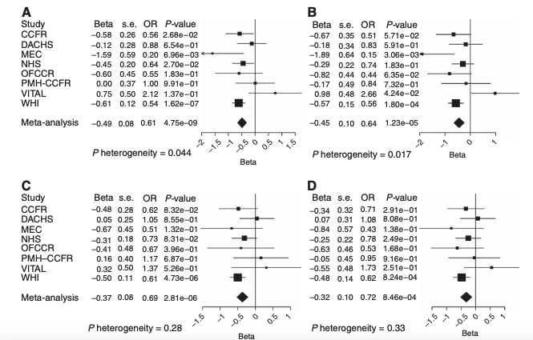

### Table from Garcia-Albeniz et al

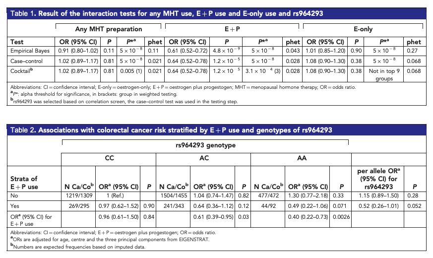

## FIGI results for rs964293

Includes entire FIGI cohort

### ep_ref_pm vs pure_ep_all

```r
exposure_subset_ep <- readRDS(glue("/media/work/gwis/data/FIGI_EpiData/FIGI_v2.3_gxeset_pure_ep_all_basic_covars_glm.rds"))[,c('vcfid', 'pure_ep_all')]

input_data_ep <- readRDS(glue("/media/work/gwis/data/FIGI_EpiData/FIGI_{hrc_version}_gxeset_analysis_data_glm.rds")) %>%
  full_join(exposure_subset_ep, 'vcfid') %>%
  filter(!is.na(ep_ref_pm))


input_data_ep %>%
  dplyr::select(hrt_ref_pm2, ep_ref_pm) %>%
  group_by(hrt_ref_pm2, ep_ref_pm) %>%
  summarise(n = n()) %>%
  gt()
```

| ep_ref_pm | n |
| --- | --- |
| No |  |
| No | 6008 |
| Yes |  |
| No | 3080 |
| Yes | 2485 |
| NA |  |
| No | 480 |

```r
input_data_ep %>%
  dplyr::select(ep_ref_pm, pure_ep_all) %>%
  group_by(ep_ref_pm, pure_ep_all) %>%
  summarise(n = n()) %>%
  gt()
```

| pure_ep_all | n |
| --- | --- |
| No |  |
| 0 | 5378 |
| NA | 4190 |
| Yes |  |
| 1 | 1509 |
| NA | 976 |

### FIGI E+P (pure_ep_all)

(important - study subsets might be missing CCFR samples - OFCCR, PMH_CCFR)

```r
# load("/media/work/gwis/data/FIGI_EpiData/Data_HRT_USC_epi_v2.3-20201204.Rdata")

exposure_subset_ep <- readRDS(glue("/media/work/gwis/data/FIGI_EpiData/FIGI_v2.3_gxeset_pure_ep_all_basic_covars_glm.rds"))[,c('vcfid', 'pure_ep_all')]
input_data_ep <- readRDS(glue("/media/work/gwis/data/FIGI_EpiData/FIGI_{hrc_version}_gxeset_analysis_data_glm.rds")) %>%
  inner_join(exposure_subset_ep, 'vcfid')

# # CCFR, DACHS, MEC, NHS, OFCCR, PMH_CCFR, VITAL, WHI
# # imperfect - missing OFCCR and PMH_CCFR
# from meta-analysis
studies <- c("CCFR", "DACHS", "DALS", "MEC", "NHS", "VITAL", "PLCO", "WHI")

# # based on supp table
studies_gxe <- c("CCFR_1", "CCFR_3", "CCFR_4","DACHS_1", "DACHS_2", "DALS_1", "DALS_2", "MEC_1", "NHS_1", "NHS_2", "PLCO_1_Rematch", "PLCO_2", "VITAL", "WHI_1_Rematch", "WHI_2")


studies_set4 <- c("CPSII_1", "CPSII_2", "Kentucky", "USC_HRT_CRC")

rs964293 <- qread("/media/work/gwis_test/hrt_ref_pm2/output/posthoc/dosage_chr20_52816717.qs") %>%
  rename(snp = chr20_52816717_C_A_dose)
rs964293_1 <- glm(outcome ~ snp * pure_ep_all + age_ref_imp + pc1 + pc2 + pc3 + study_gxe,
                     data = inner_join(input_data_ep, rs964293, 'vcfid') %>%
                     filter(study %in% studies), family = 'binomial')
# summary(rs964293_1)


rs964293_2 <- glm(outcome ~ snp * pure_ep_all + age_ref_imp + pc1 + pc2 + pc3 + study_gxe,
                     data = inner_join(input_data_ep, rs964293, 'vcfid') %>%
                     filter(study_gxe %in% studies_gxe), family = 'binomial')
# summary(rs964293_2)

rs964293_dg <- glm(outcome ~ snp * pure_ep_all + age_ref_imp + pc1 + pc2 + pc3 + study_gxe,
                     data = inner_join(input_data_ep, rs964293, 'vcfid'), family = 'binomial')

# set4
rs964293_4 <- glm(outcome ~ snp * pure_ep_all + age_ref_imp + pc1 + pc2 + pc3 + study_gxe,
                     data = inner_join(input_data_ep, rs964293, 'vcfid') %>%
                     filter(study_gxe %in% studies_set4), family = 'binomial')



list_of_glms <- list(rs964293_1, rs964293_2, rs964293_4, rs964293_dg)
coefs <- lapply(list_of_glms, function(x) (exp(coef(x))))

stargazer(list_of_glms, align = T,
          type = 'html',
          ci = TRUE,
          ci.level = 0.95,
          keep.stat = "n",
          star.cutoffs = c(0.05, 0.01, 0.001),
          coef = coefs,
          omit = c("pc"),
          p.auto = F,
          single.row = T,
          column.sep.width = '20pt',
          report = ('vcsp'),
          column.labels = c("study subset 1", "study subset 2", "study subset 3", "FIGI"))
```

|  | *Dependent variable:* |  |  |  |
| --- | --- | --- | --- | --- |
|  | outcome |  |  |  |
|  | study subset 1 | study subset 2 | study subset 3 | FIGI |
|  | (1) | (2) | (3) | (4) |
| snp | 1.022 (0.932, 1.112) | 1.106 (0.980, 1.231) | 1.087 (0.911, 1.264) | 1.034 (0.954, 1.114) |
|  | p = 0.631 | p = 0.117 | p = 0.353 | p = 0.411 |
| pure_ep_all | 0.853 (0.655, 1.050) | 0.907 (0.643, 1.170) | 0.634 (0.299, 0.969) | 0.783 (0.614, 0.952) |
|  | p = 0.115 | p = 0.468 | p = 0.008 | p = 0.005 |
| age_ref_imp | 0.989 (0.981, 0.997) | 0.982 (0.972, 0.993) | 0.979 (0.964, 0.994) | 0.987 (0.980, 0.994) |
|  | p = 0.009 | p = 0.001 | p = 0.007 | p = 0.0004 |
| study_gxeCCFR_3 | 2.306 (2.050, 2.562) | 2.373 (2.116, 2.631) |  | 2.324 (2.068, 2.580) |
|  | p = 0.000 | p = 0.000 |  | p = 0.000 |
| study_gxeCCFR_4 | 4.088 (3.794, 4.383) | 4.163 (3.867, 4.459) |  | 4.083 (3.788, 4.377) |
|  | p = 0.000 | p = 0.000 |  | p = 0.000 |
| study_gxeCPSII_1 |  |  |  | 1.732 (1.455, 2.008) |
|  |  |  |  | p = 0.0001 |
| study_gxeNHS_1_2 | 0.667 (0.410, 0.923) |  |  | 0.667 (0.410, 0.923) |
|  | p = 0.002 |  |  | p = 0.002 |
| study_gxeNHS_3_AD | 1.665 (1.383, 1.948) |  |  | 1.657 (1.375, 1.939) |
|  | p = 0.0005 |  |  | p = 0.0005 |
| study_gxeWHI_1 | 1.298 (1.057, 1.538) |  |  | 1.321 (1.082, 1.559) |
|  | p = 0.034 |  |  | p = 0.023 |
| study_gxeWHI_2 | 1.477 (1.264, 1.690) | 1.536 (1.318, 1.754) |  | 1.494 (1.283, 1.705) |
|  | p = 0.0004 | p = 0.0002 |  | p = 0.0002 |
| study_gxeWHI_3 | 1.505 (1.276, 1.735) |  |  | 1.515 (1.286, 1.743) |
|  | p = 0.0005 |  |  | p = 0.0004 |
| study_gxeCPSII_2 |  |  | 0.860 (0.545, 1.175) | 1.459 (1.154, 1.765) |
|  |  |  | p = 0.348 | p = 0.016 |
| study_gxeKentucky |  |  | 0.803 (0.526, 1.080) | 1.408 (1.149, 1.666) |
|  |  |  | p = 0.121 | p = 0.010 |
| study_gxeUSC_HRT_CRC |  |  | 0.654 (0.365, 0.942) | 1.190 (0.924, 1.456) |
|  |  |  | p = 0.004 | p = 0.200 |
| snp:pure_ep_all | 0.771 (0.568, 0.975) | 0.727 (0.449, 1.005) | 1.149 (0.819, 1.480) | 0.873 (0.701, 1.044) |
|  | p = 0.013 | p = 0.025 | p = 0.410 | p = 0.121 |
| Constant | 1.808 (1.235, 2.381) | 2.665 (1.937, 3.394) | 3.760 (2.607, 4.914) | 1.877 (1.366, 2.389) |
|  | p = 0.043 | p = 0.009 | p = 0.025 | p = 0.016 |
| Observations | 5,332 | 2,901 | 1,555 | 6,887 |
| *Note:* | p<0.05; p<0.01; p<0.001 |  |  |  |

### FIGI E+P (ep_ref_pm)

(important - study subsets might be missing CCFR samples - OFCCR, PMH_CCFR)

```r
load("/media/work/gwis/data/FIGI_EpiData/Data_HRT_USC_epi_v2.3-20201204.Rdata")

# exposure_subset_ep <- readRDS(glue("/media/work/gwis/data/FIGI_EpiData/FIGI_v2.3_gxeset_pure_ep_all_basic_covars_glm.rds"))[,c('vcfid', 'pure_ep_all')]
input_data_ep <- readRDS(glue("/media/work/gwis/data/FIGI_EpiData/FIGI_{hrc_version}_gxeset_analysis_data_glm.rds"))

# # CCFR, DACHS, MEC, NHS, OFCCR, PMH_CCFR, VITAL, WHI
# # imperfect - missing OFCCR and PMH_CCFR
# from meta-analysis
studies <- c("CCFR", "DACHS", "DALS", "MEC", "NHS", "VITAL", "PLCO", "WHI")

# # based on supp table
studies_gxe <- c("CCFR_1", "CCFR_3", "CCFR_4","DACHS_1", "DACHS_2", "DALS_1", "DALS_2", "MEC_1", "NHS_1", "NHS_2", "PLCO_1_Rematch", "PLCO_2", "VITAL", "WHI_1_Rematch", "WHI_2")


studies_set4 <- c("CPSII_1", "CPSII_2", "CLUEII", "NFCCR_2", "Kentucky", "USC_HRT_CRC", "REACH_AD")

rs964293 <- qread("/media/work/gwis_test/hrt_ref_pm2/output/posthoc/dosage_chr20_52816717.qs") %>%
  rename(snp = chr20_52816717_C_A_dose)
rs964293_1 <- glm(outcome ~ snp * ep_ref_pm + age_ref_imp + pc1 + pc2 + pc3 + study_gxe,
                     data = inner_join(input_data_ep, rs964293, 'vcfid') %>%
                     filter(study %in% studies), family = 'binomial')
# summary(rs964293_1)


rs964293_2 <- glm(outcome ~ snp * ep_ref_pm + age_ref_imp + pc1 + pc2 + pc3 + study_gxe,
                     data = inner_join(input_data_ep, rs964293, 'vcfid') %>%
                     filter(study_gxe %in% studies_gxe), family = 'binomial')
# summary(rs964293_2)

rs964293_dg <- glm(outcome ~ snp * ep_ref_pm + age_ref_imp + pc1 + pc2 + pc3 + study_gxe,
                     data = inner_join(input_data_ep, rs964293, 'vcfid'), family = 'binomial')

# set4
rs964293_4 <- glm(outcome ~ snp * ep_ref_pm + age_ref_imp + pc1 + pc2 + pc3 + study_gxe,
                     data = inner_join(input_data_ep, rs964293, 'vcfid') %>%
                     filter(study_gxe %in% studies_set4), family = 'binomial')


list_of_glms <- list(rs964293_1, rs964293_2, rs964293_4, rs964293_dg)
coefs <- lapply(list_of_glms, function(x) (exp(coef(x))))

stargazer(list_of_glms, align = T,
          type = 'html',
          ci = TRUE,
          ci.level = 0.95,
          keep.stat = "n",
          star.cutoffs = c(0.05, 0.01, 0.001),
          coef = coefs,
          omit = c("pc"),
          p.auto = F,
          single.row = T,
          column.sep.width = '20pt',
          report = ('vcsp'),
          column.labels = c("study subset 1", "study subset 2", "study subset 3", "FIGI"))
```

|  | *Dependent variable:* |  |  |  |
| --- | --- | --- | --- | --- |
|  | outcome |  |  |  |
|  | study subset 1 | study subset 2 | study subset 3 | FIGI |
|  | (1) | (2) | (3) | (4) |
| snp | 1.055 (0.986, 1.124) | 1.127 (1.025, 1.229) | 1.040 (0.916, 1.163) | 1.051 (0.991, 1.111) |
|  | p = 0.128 | p = 0.022 | p = 0.536 | p = 0.107 |
| ep_ref_pmYes | 0.989 (0.838, 1.140) | 0.980 (0.754, 1.207) | 0.731 (0.466, 0.997) | 0.916 (0.785, 1.047) |
|  | p = 0.887 | p = 0.863 | p = 0.021 | p = 0.191 |
| age_ref_imp | 0.993 (0.987, 0.999) | 0.988 (0.979, 0.996) | 0.989 (0.978, 0.999) | 0.992 (0.987, 0.997) |
|  | p = 0.031 | p = 0.005 | p = 0.034 | p = 0.004 |
| study_gxeCCFR_3 | 2.421 (2.199, 2.644) | 2.469 (2.245, 2.693) |  | 2.427 (2.204, 2.649) |
|  | p = 0.000 | p = 0.000 |  | p = 0.000 |
| study_gxeCCFR_4 | 4.614 (4.356, 4.872) | 4.663 (4.405, 4.922) |  | 4.605 (4.348, 4.863) |
|  | p = 0.000 | p = 0.000 |  | p = 0.000 |
| study_gxeCLUEII |  |  |  | 1.537 (1.228, 1.846) |
|  |  |  |  | p = 0.007 |
| study_gxeMEC_1 | 1.295 (0.981, 1.608) | 1.325 (1.010, 1.641) |  | 1.301 (0.987, 1.614) |
|  | p = 0.107 | p = 0.081 |  | p = 0.100 |
| study_gxeMEC_2 | 0.718 (0.056, 1.379) |  |  | 0.721 (0.061, 1.381) |
|  | p = 0.326 |  |  | p = 0.332 |
| study_gxeNHS_1_2 | 0.695 (0.489, 0.900) |  |  | 0.695 (0.489, 0.901) |
|  | p = 0.001 |  |  | p = 0.001 |
| study_gxeNHS_3_AD | 1.745 (1.531, 1.959) |  |  | 1.744 (1.530, 1.958) |
|  | p = 0.00000 |  |  | p = 0.00000 |
| study_gxeNHS_4 | 1.454 (1.213, 1.695) |  |  | 1.469 (1.230, 1.708) |
|  | p = 0.003 |  |  | p = 0.002 |
| study_gxeNHS_5_AD | 1.725 (1.476, 1.974) |  |  | 1.740 (1.492, 1.988) |
|  | p = 0.00002 |  |  | p = 0.00002 |
| study_gxeVITAL | 1.354 (1.051, 1.657) | 1.425 (1.117, 1.733) |  | 1.374 (1.072, 1.676) |
|  | p = 0.051 | p = 0.025 |  | p = 0.040 |
| study_gxeWHI_1 | 1.321 (1.113, 1.529) |  |  | 1.332 (1.125, 1.539) |
|  | p = 0.009 |  |  | p = 0.007 |
| study_gxeWHI_2 | 1.489 (1.304, 1.674) | 1.537 (1.348, 1.727) |  | 1.499 (1.314, 1.683) |
|  | p = 0.00003 | p = 0.00001 |  | p = 0.00002 |
| study_gxeWHI_3 | 1.507 (1.307, 1.707) |  |  | 1.513 (1.314, 1.712) |
|  | p = 0.0001 |  |  | p = 0.00005 |
| study_gxeCPSII_1 |  |  | 1.040 (0.722, 1.359) | 1.551 (1.313, 1.789) |
|  |  |  | p = 0.809 | p = 0.0004 |
| study_gxeCPSII_2 |  |  | 0.992 (0.651, 1.333) | 1.471 (1.204, 1.738) |
|  |  |  | p = 0.964 | p = 0.005 |
| study_gxeKentucky |  |  | 0.784 (0.482, 1.086) | 1.164 (0.955, 1.372) |
|  |  |  | p = 0.114 | p = 0.155 |
| study_gxeNFCCR_2 |  |  | 0.423 (0.005, 0.840) | 0.648 (0.292, 1.003) |
|  |  |  | p = 0.0001 | p = 0.017 |
| study_gxeREACH_AD |  |  | 0.112 (-0.669, 0.893) | 0.169 (-0.581, 0.920) |
|  |  |  | p = 0.00000 | p = 0.00001 |
| study_gxeUSC_HRT_CRC |  |  | 0.761 (0.450, 1.071) | 1.145 (0.925, 1.366) |
|  |  |  | p = 0.085 | p = 0.229 |
| snp:ep_ref_pmYes | 0.800 (0.642, 0.958) | 0.734 (0.492, 0.976) | 1.064 (0.806, 1.322) | 0.865 (0.730, 0.999) |
|  | p = 0.006 | p = 0.013 | p = 0.639 | p = 0.034 |
| Constant | 1.212 (0.770, 1.654) | 1.681 (1.080, 2.282) | 2.001 (1.186, 2.816) | 1.238 (0.847, 1.629) |
|  | p = 0.394 | p = 0.091 | p = 0.096 | p = 0.285 |
| Observations | 9,111 | 4,254 | 2,942 | 12,053 |
| *Note:* | p<0.05; p<0.01; p<0.001 |  |  |  |

```r
#### ORIGINAL (GENOTYPES)
stratified_or_file <- readRDS(glue("/media/work/gwis_test/hrt_ref_pm2/output/posthoc/stratified_oddsratio_hrt_ref_pm2_v2.3_chr20_52816717_C_A_age_ref_imp_pc1_pc2_pc3_study_gxe.rds"))

options(knitr.kable.NA = '')
kable(stratified_or_file) %>%
  kable_styling('bordered', bootstrap_options = c("striped", "hover", "condensed"), full_width = F, position = 'left') %>%
  add_header_above(c(" " = 4, "G param by E" = 2, "Counts (Ca/Co)" = 3)) %>%
  # add_header_above(c(" " = 4, "G param by E" = 2)) %>%
  pack_rows("E param by G", 5, 6, indent = F)
```

|  | CC | CA | AA | G param by E CA | G param by E AA | Counts (Ca/Co) N0 | Counts (Ca/Co) N1 | Counts (Ca/Co) N2 |
| --- | --- | --- | --- | --- | --- | --- | --- | --- |
| hrt_ref_pm2=No | 1 | 1.02 (0.95-1.09) | 1 (0.91-1.11) | 1.02 (0.95-1.09) | 1 (0.91-1.11) | 2981.3/4241.6 | 3595.6/5054.8 | 1087.1/1498.6 |
| p0 | P= 1 | P= 0.66 | P= 0.94 | P= 0.66 | P= 0.94 |  |  |  |
| hrt_ref_pm2=Yes | 0.71 (0.65-0.77) | 0.71 (0.66-0.78) | 0.66 (0.58-0.75) | 1 (0.92-1.1) | 0.93 (0.81-1.06) | 1593.8/2533.1 | 1767.6/2812.6 | 493.6/826.3 |
| p1 | P= 5.2e-15 | P= 2e-15 | P= 2.3e-10 | P= 0.92 | P= 0.27 |  |  |  |
| **E param by G** |  |  |  |  |  |  |  |  |
| hrt_ref_pm2 | 0.71 (0.65-0.77) | 0.7 (0.65-0.76) | 0.66 (0.57-0.76) |  |  |  |  |  |
| p | P= 5.2e-15 | P= 1e-17 | P= 1.3e-08 |  |  |  |  |  |

### Regional plot

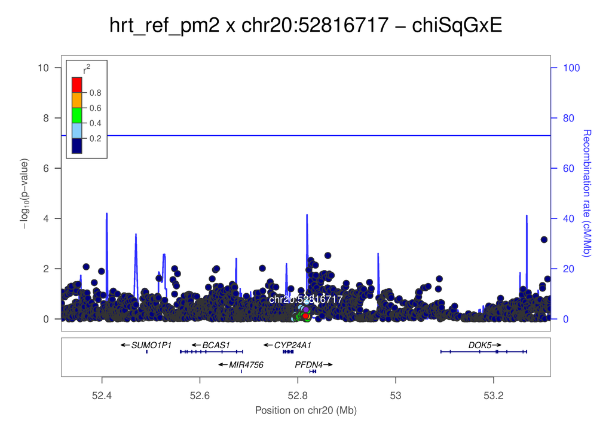

```r
# locuszoom plot
locuszoom_png <- glue("/media/work/gwis_test/hrt_ref_pm2/output/locuszoom_plot/locuszoom_plot_hrt_ref_pm2_v2.3_chiSqGxE_chr20_52816717.png")
knitr::include_graphics(locuszoom_png)
```